# EAS 635.001 Homework 2

Author

Xiuyu Cao

Published

October 9, 2024

**Homework 2 aims to assess your ability to (1) calculate various characteristics of a random variable and a multivariate dataset, (2) determine whether or not variables in a dataset follow a normal distribution, and (3) perform a PCA.**

**There are 4 questions total. Please be sure to submit your R code as well as the output in one of the following formats for full credit: .pdf, .html**

```r
## setup
library(tidyverse)
```

## 1 QUESTION 1

**For Q1-Q4, load in and use the data from the `forestfires.csv` file. The dataset has been sourced from https://archive.ics.uci.edu/dataset/162/forest+fires , there are multiple sites with different coordinates(X & Y) in the dataset, which is recorded with multiple forest fire events and the corresponding weather conditions.**

```r
### LOAD IN CSV FILE ("forestfires.csv")
fires <- read.csv('../data/hw02/forestfires.csv')
```

### 1.1 PART A

**Produce and show (1) a variance-covariance matrix and (2) a correlation matrix for the `fires` dataset. Please exclude any rows with missing data(NA values) first and exclude any variables that are inappropriate for these matrices.**

**Hints: (1 The step of removing rows with NA values is very important since many functions used in multivariate analysis don’t accepct NA values as the input (2 there are 12 columns in total of the data, but not all of them are meaningful to be used as the input of following analysis, please check the data table as well as the source website and determine which variables you are going to use**

```r
## get variance-covariance and correlation matrices
fires.continuous <- fires %>%
  na.omit() %>%
  select(FFMC:area)

mat.cov <- cov(fires.continuous)  # variance-covariance matrix
mat.cov
```

```
            FFMC         DMC           DC        ISI        temp          RH
FFMC   8.8372727   91.068889   226.692475  9.7773737   6.8981313  -10.565657
DMC   91.0688889 4541.068065  8490.398853 55.2474788 141.1339232   10.000687
DC   226.6924747 8490.398853 45173.391736 13.3787717 521.4025646 -691.970424
ISI    9.7773737   55.247479    13.378772 38.2224485   6.1135394   -6.896889
temp   6.8981313  141.133923   521.402565  6.1135394  28.8685444  -61.005374
RH   -10.5656566   10.000687  -691.970424 -6.8968889 -61.0053737  293.629899
wind  -0.7209091   -8.113560   -54.067933  1.1428848  -2.3775495    4.712646
rain   0.4076768    5.068251     7.909119  0.3860687   0.5889576    1.510465
area  21.9128737  606.624803   539.962815 19.0267386  67.4038411 -152.685956
            wind       rain         area
FFMC  -0.7209091  0.4076768   21.9128737
DMC   -8.1135596  5.0682505  606.6248032
DC   -54.0679333  7.9091192  539.9628148
ISI    1.1428848  0.3860687   19.0267386
temp  -2.3775495  0.5889576   67.4038411
RH     4.7126465  1.5104646 -152.6859556
wind   3.2248121  0.1096485   13.6976543
rain   0.1096485  0.4286222   -0.9329491
area  13.6976543 -0.9329491 6644.8804842
```

```r
mat.cor <- cor(fires.continuous)  # correlation matrix
mat.cor
```

```
            FFMC          DMC          DC         ISI       temp           RH
FFMC  1.00000000  0.454602587  0.35878694  0.53199045  0.4318768 -0.207413597
DMC   0.45460259  1.000000000  0.59279937  0.13260937  0.3897983  0.008660654
DC    0.35878694  0.592799375  1.00000000  0.01018159  0.4565826 -0.189996694
ISI   0.53199045  0.132609368  0.01018159  1.00000000  0.1840437 -0.065101926
temp  0.43187681  0.389798322  0.45658261  0.18404373  1.0000000 -0.662606223
RH   -0.20741360  0.008660654 -0.18999669 -0.06510193 -0.6626062  1.000000000
wind -0.13504209 -0.067047134 -0.14165967  0.10294162 -0.2464137  0.153148418
rain  0.20946887  0.114879285  0.05683939  0.09538234  0.1674304  0.134639684
area  0.09042669  0.110432670  0.03116585  0.03775387  0.1538965 -0.109308860
            wind        rain        area
FFMC -0.13504209  0.20946887  0.09042669
DMC  -0.06704713  0.11487929  0.11043267
DC   -0.14165967  0.05683939  0.03116585
ISI   0.10294162  0.09538234  0.03775387
temp -0.24641374  0.16743037  0.15389645
RH    0.15314842  0.13463968 -0.10930886
wind  1.00000000  0.09326380  0.09357297
rain  0.09326380  1.00000000 -0.01748143
area  0.09357297 -0.01748143  1.00000000
```

**1) Which two variables in the `fires` dataset are most highly correlated? (use code to identify)**

**Extra Credit Opportunity: You could write your own function in R to help you calculate and return the most highly correlated variables, the basic structure of R function could be found in section 2.5 of Zelterman**

```r
## get the most highly correlated variables
res <- as.data.frame(mat.cor) %>%
  mutate(var1 = rownames(.)) %>%
  gather(var2, cor, -var1) %>%
  filter(var1 != var2) %>%
  arrange(desc(cor))

res[1,]  # most highly correlated variables
```

```
  var1 var2       cor
1   DC  DMC 0.5927994
```

**2) Which two variables have the greatest covariance (absolute value)? Which variable has the smallest variance? (use code to identify)**

ANSWER (FOR GREATEST COVARIANCE):

```r
## get the greatest covariance
res <- as.data.frame(mat.cov) %>%
  mutate(var1 = rownames(.)) %>%
  gather(var2, cov, -var1) %>%
  filter(var1 != var2) %>%
  arrange(desc(abs(cov)))

res[1,]  # greatest covariance
```

```
  var1 var2      cov
1   DC  DMC 8490.399
```

ANSWER (FOR SMALLEST VARIANCE):

```r
## get the smallest variance
res <- as.data.frame(mat.cov) %>%
  mutate(var1 = rownames(.)) %>%
  gather(var2, cov, -var1) %>%
  filter(var1 == var2) %>%
  arrange(cov)

res[1,]  # smallest variance
```

```
  var1 var2       cov
1 rain rain 0.4286222
```

### 1.2 PART B

**Calculate the Euclidean distances between all possible pairs of samples gained at the sites whose id is 75 (should be 8 total samples) with AND without scaling the variables beforehand. Print the output of the 2 distance matrices.**

```r
### ENTER CODE FOR Q1 PART B HERE
dat2calc <- fires %>%
  na.omit() %>%
  filter(id == 75) %>%
  select(FFMC:area)

## calculate Euclidean distances
dist.unscaled <- dist(dat2calc, method = "euclidean")  # without scaling
dist.unscaled
```

```
          1         2         3         4         5         6         7
2 607.76876
3 621.00564  26.13408
4 607.72425  45.53021  64.30000
5  93.01236 696.94692 709.91994 697.64224
6 370.57586 283.44633 302.28965 267.52637 459.67766
7 598.04712 100.95178 119.65481  63.31141 687.39336 241.31834
8 597.80407 100.55377 119.18544  65.48588 687.15520 241.07157  13.59862
```

```r
dist.scaled <- dist(scale(dat2calc), method = "euclidean")  # with scaling
dist.scaled
```

```
         1        2        3        4        5        6        7
2 3.944707
3 4.578323 2.544560
4 5.030196 2.852682 3.807794
5 3.430237 4.702180 5.501358 5.271270
6 4.798696 2.324947 3.079574 3.064708 4.564388
7 6.127005 4.216088 4.518809 4.333911 6.521980 4.217483
8 4.687056 2.662332 2.941775 3.970103 5.305293 2.597727 3.128030
```

**Then, produce two dendrograms, one for each distance matrix (scaled and unscaled). To do so you can use the `hclust()` function with the distance matrix as input, and then use `plot()` on the output (please refer to textbook Zelterman 2015 page 288). No need for axes labels but please add a title. You are also encouraged to use other functions. Just make sure you understand the function you are using.**

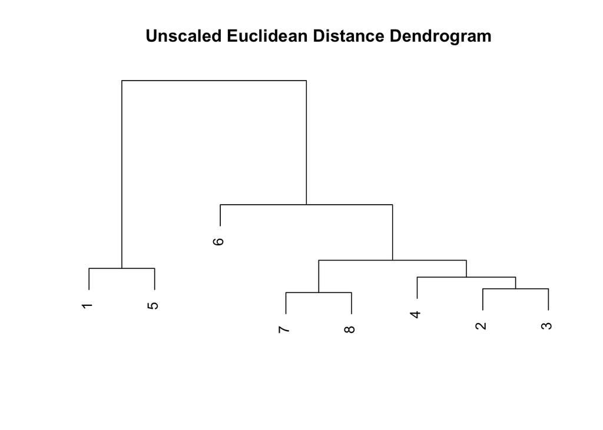

```r
### ENTER CODE FOR Q1 PART B HERE
hclust.unscaled <- hclust(dist.unscaled)
plot(hclust.unscaled,
     xlab='', sub='', ylab='', yaxt='n',
     main = "Unscaled Euclidean Distance Dendrogram")
```

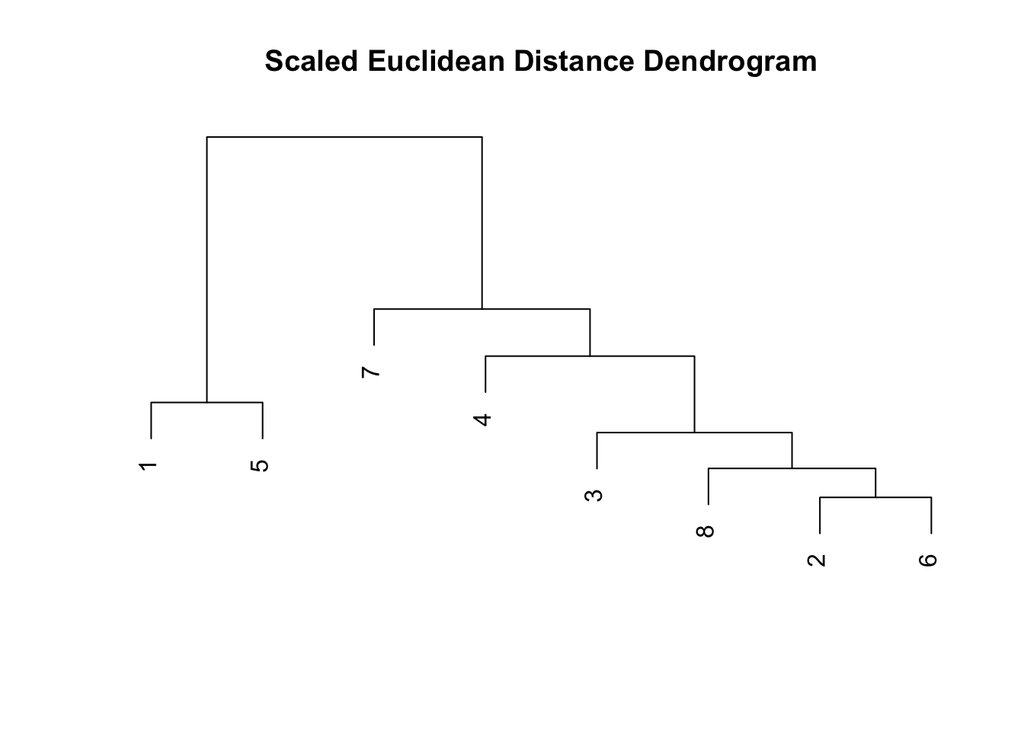

```r
hclust.scaled <- hclust(dist.scaled)
plot(hclust.scaled,
     xlab='', sub='', ylab='', yaxt='n',
     main = "Scaled Euclidean Distance Dendrogram")
```

**Use your results to answer the two questions below:**

**1) Why might scaling your variables be a necessary step to take before calculating the distances between samples?**

ANSWER: When variables have different scales (e.g. 0 - 1 v.s. 0 - 1,000), the distance result will be dominated by the ones with larger scales.

**2) Which two forest fires samples from id 75 (row #1 - #8) are the most similar? Which two are the most different? (use code to process the scaled distance matrix to get the result)**

```r
### ENTER CODE FOR Q1 PART B HERE
res <- as.matrix(dist.scaled)
res[lower.tri(res)] <- NA
res <- as.data.frame(res) %>%
  mutate(var1 = rownames(.)) %>%
  gather(var2, dist, -var1) %>%
  na.omit() %>%
  filter(var1 != var2) %>%
  arrange(dist)

res[1,]  # most similar
```

```
  var1 var2     dist
1    2    6 2.324947
```

```r
res[nrow(res),]  # most different
```

```
   var1 var2    dist
28    5    7 6.52198
```

### 1.3 PART C

**Calculate the “Canberra” distances between all possible pairs of all samples (except for the samples that were filtered out in Part A) in the `fires` dataset. No need to print the output.Then produce and show a dendrogram based on the “Canberra” distances.**

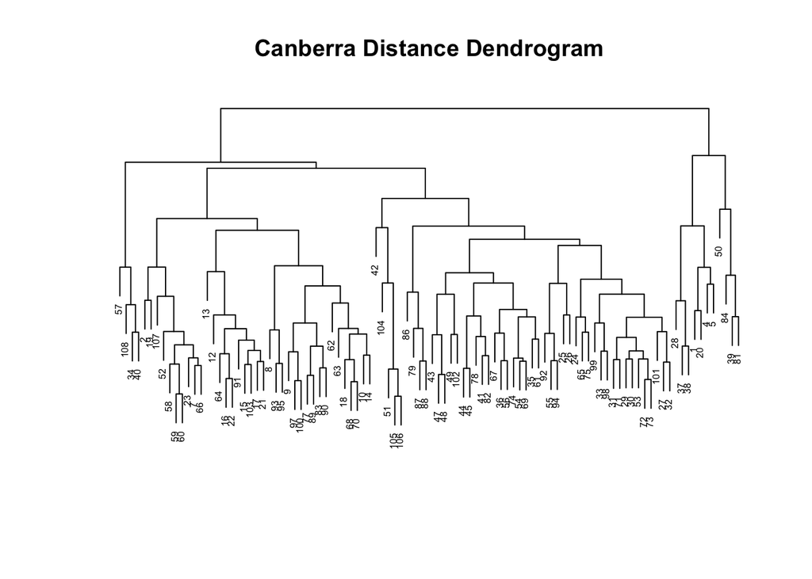

```r
### ENTER CODE FOR Q1 PART C HERE
dat2calc <- fires %>%
  na.omit() %>%
  select(FFMC:area)

dist.canberra <- dist(dat2calc, method = "canberra")
hclust.canberra <- hclust(dist.canberra)
plot(hclust.canberra,
     xlab='', sub='', ylab='', yaxt='n',
     cex = .5,
     main = "Canberra Distance Dendrogram")
```

## 2 QUESTION 2

### 2.1 PART A

**Produce a density plot of `temp` in the `fires` dataset without null values. Then, superimpose a plot of the normal probability density function for a variable with the same mean and standard deviation as the `temp` variable. Make the density plot blue and the normal probability density function red to distinguish between them. Make sure to appropriately label the plot axes and add a legend. Lines should be shown, not discrete points. (To clarify: there should only be one plot produced, but two curves plotted.)**

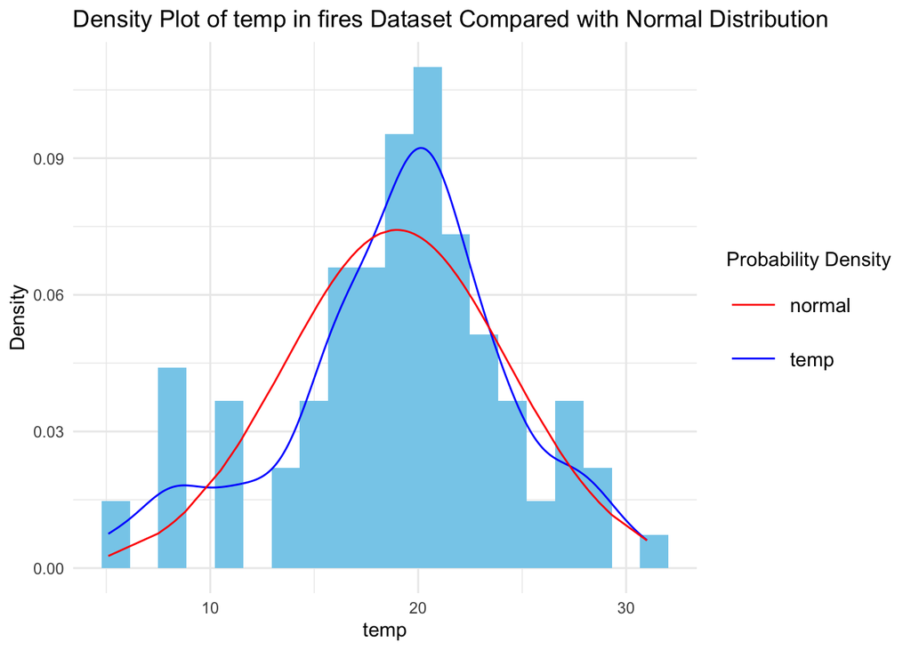

```r
### ENTER CODE FOR Q2 PART A HERE
data2plot <- fires %>%
  na.omit() %>%
  select(temp) %>%
  mutate(d.norm=dnorm(x=temp, mean=mean(temp), sd=sd(temp)))

ggplot() +
  theme_minimal() +
  geom_histogram(data=data2plot, aes(x = temp, y=..density..), fill='skyblue', color=NA, bins = 20) +
  stat_density(data=data2plot, aes(x = temp, color='temp'), geom='line') +
  geom_line(data=data2plot, aes(x = temp, y=d.norm, color='normal')) +
  scale_color_manual(name='Probability Density',
                     values = c('temp'='blue','normal'='red'),
                     guide = guide_legend(override.aes = list(size = 10))) +
  labs(title = "Density Plot of temp in fires Dataset Compared with Normal Distribution",
       x = "temp", y = "Density") +
  theme(legend.text=element_text(size=11))
```

### 2.2 PART B

**Produce TWO different plots (should be different types, normally we expect you to plot QQ plot and histogram, but other types of plots that could help address this situation are encouraged as well) to visually check for the normality of `temp` in the filtered `fires` dataset. Comment on whether or not the data for this variable is normally distributed and how you were able to determine this from the plots you produced.**

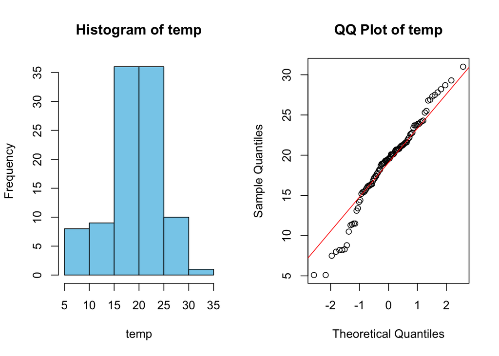

```r
### ENTER CODE FOR Q2 PART B HERE
data2plot <- fires %>%
  na.omit() %>%
  select(temp)

par(mfrow=c(1,2))
hist(data2plot$temp, col='skyblue', main='Histogram of temp', xlab='temp', ylab='Frequency')
qqnorm(data2plot$temp, main='QQ Plot of temp')
qqline(data2plot$temp, col='red')
```

COMMENT: From the histogram, the data has a light skew. From the Q-Q plot, the middle portion of the data is close to normal distribution, with extremes deviating from the normal distribution

### 2.3 PART C

**An arguably better way to test whether or not a variable is normally distributed, as opposed to producing a plot, is to use the Shapiro-Wilk test (`shapiro.test()`). The input is a vector of data and the output is the test statistic *W* and an associated p-value. If the p-value is less than the chosen $\alpha$, usually $\alpha = 0.05$, we reject the null hypothesis of the test, which is that the data are normally distributed, and conclude that the data are not normally distributed. For more information on the `shapiro.test()` function and an example of how to use it, type `?shapiro.test` in the console.**

**Now, use the Shapiro-Wilk normality test to test whether or not `temp` is normally distributed. Print your W and p-values. Comment on your results: are the data normally distributed or not?**

```r
### ENTER CODE FOR Q2 PART C HERE
shapiro.test(data2plot$temp)
```

```
    Shapiro-Wilk normality test

data:  data2plot$temp
W = 0.97187, p-value = 0.03077
```

COMMENT: The p-value is less than $\alpha=0.05$, we reject the null hypothesis, the data are not normally distributed.

## 3 QUESTION 3

### 3.1 PART A

**Calculate and print the Mahalanobis distance for each row of the `fires` dataset.**

```r
### ENTER CODE FOR Q3 PART A HERE
dat2calc <- fires %>%
  na.omit() %>%
  select(FFMC:area)

mahalanobis.dist <- mahalanobis(dat2calc, colMeans(dat2calc), cov(dat2calc))
mahalanobis.dist
```

```
        1         2         4         5         7         8         9        10
10.434951  8.237785 16.199015 18.125744  3.146763  9.710678  3.254953  3.546741
       12        13        14        15        16        17        18        19
 8.422130 70.116946  2.223730  5.060826  1.284498  3.323112  2.706105  6.814791
       20        21        22        23        24        25        26        27
12.750856  4.101134  1.103094  3.470786 11.121423  5.147068  7.369409  3.308663
       28        29        30        31        32        33        34        35
10.571866  2.685839  3.805073  5.120686  1.491530  2.546948  9.190961  4.445259
       36        37        38        39        40        41        42        43
 2.438595 10.071774  7.913093 12.710882  5.223433  1.914347 15.779734  4.474797
       44        45        47        48        49        50        51        52
 1.674677  3.572651  1.887024  2.311626  5.831898 19.775387 11.506136  4.140714
       53        54        55        56        57        58        59        60
 1.192489  3.274395  3.163994  1.715483 14.048993  2.517676  3.367394  3.504980
       61        62        63        64        65        66        67        68
 4.225395  6.085604  4.887340  3.235051  3.255484  3.115857  3.365494  2.838820
       69        70        71        72        73        74        75        77
 2.791985  4.496311  3.271941  1.903878  2.282809  2.953756  7.836295  3.029446
       78        79        81        82        83        84        86        87
 3.271036  6.525716  9.096693  2.572562  2.615960 16.806732 80.553465 12.733201
       88        89        90        91        92        93        94        95
 5.340229  5.536156 11.935335  7.318352  5.440854 10.562694  5.025723 16.516407
       97        98        99       100       101       102       103       104
 4.491415  5.180246 13.361766  5.217671 12.150514 15.716587 11.652217 93.826387
      105       106       107       108
 6.283500  6.283500 24.241421 26.316657
```

### 3.2 PART B

**Produce a plot to determine if the `fires` data come from a multivariate normal distribution.**

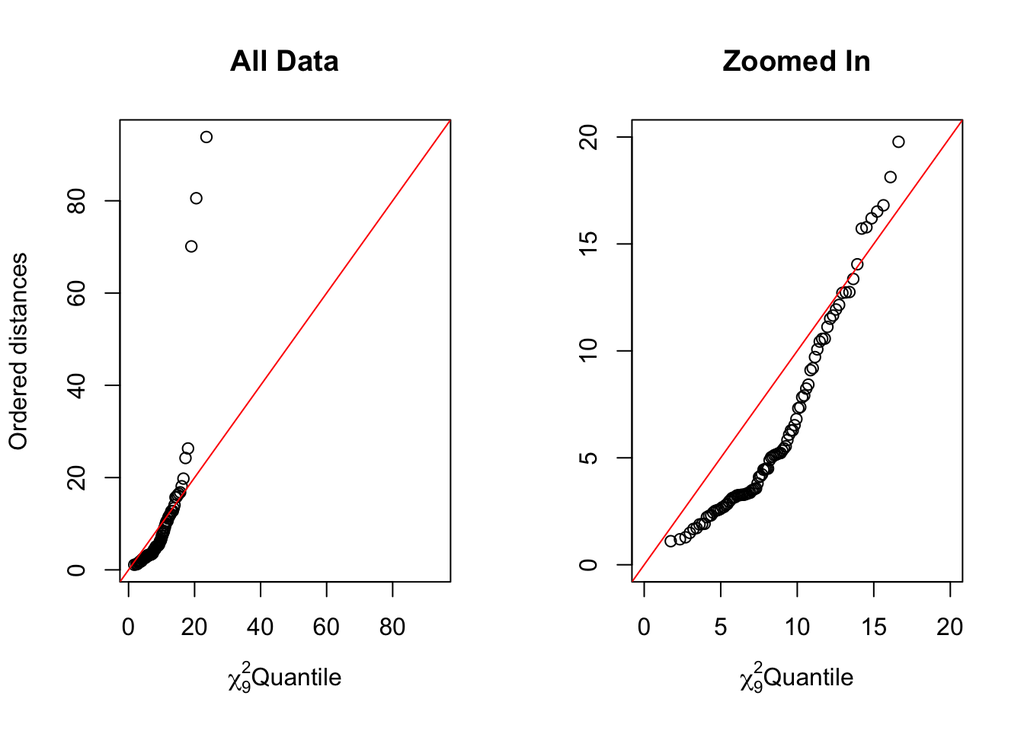

```r
### ENTER CODE FOR Q3 PART B HERE
qq.x <- qchisq((1:nrow(dat2calc)-0.5)/nrow(dat2calc), df = 9)
qq.y <- sort(mahalanobis.dist)

par(mfrow=c(1,2))

range1 <- range(c(qq.x, qq.y))
plot(qq.x, qq.y,
     xlab = expression(paste(chi[9]^2, "Quantile")),
     ylab = "Ordered distances",
     xlim = range1, ylim = range1,
     main = 'All Data')
abline(a = 0, b = 1, col = "red")

range2 <- c(0, 20)
plot(qq.x, qq.y,
     xlab = expression(paste(chi[9]^2, "Quantile")),
     ylab = "",
     xlim = range2, ylim = range2,
     main = 'Zoomed In')
abline(a = 0, b = 1, col = "red")
```

### 3.3 PART C

**Answer the two questions below:**

**1) If data in a multivariate dataset come from a multivariate normal distribution, what kind of distribution will the Mahalanobis distance values follow? How do you determine the degrees of freedom? (Note: your answers should be general, not specific to any dataset.)**

ANSWER: The Mahalanobis distance values will follow a chi-squared distribution (df = number of variables (ncol)).

**2) Regarding the plot you made in Part B, do the data come from a multivariate normal distribution? Explain how you came to this conclusion. (i.e., What would you expect to see if data come from a multivariate normal distribution, and does your plot meet these expectations?)**

ANSWER: If the data come from a multivariate normal distribution, the Mahalanobis distance values should follow a straight line. The plot does not show a straight line. Most of the data fall out of the straight line, only a few data points are close to the line. There are also some extreme outliers.

## 4 QUESTION 4

### 4.1 PART A

**Conduct TWO principal components analysis (using whichever package and function you choose) of the `fires` data: one where the calculation uses the covariance matrix and one where the correlation matrix is used.**

```r
### ENTER CODE FOR Q4 PART A HERE
dat2calc <- fires %>%
  na.omit() %>%
  select(FFMC:area)

## PCA using covariance matrix
pca.cov <- princomp(dat2calc, cor = F, scores = T)

## PCA using correlation matrix
pca.cor <- princomp(dat2calc, cor = T, scores = T)
```

### 4.2 PART B

**Report the number of components you think you need to explain the data and how much variance would be explained by your decision. Justify your decision by both summary your PCA result and displaying a plot showing the cumulative proportion of variance explained by each component.**

**Do this for both PCAs you performed in Part A.**

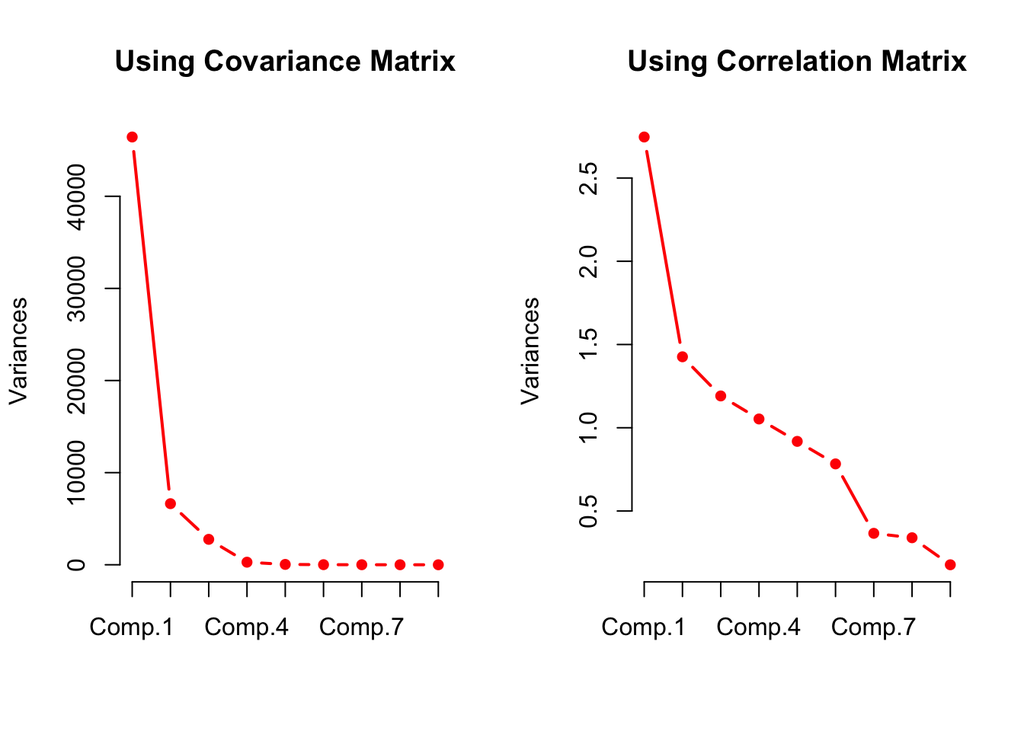

```r
### ENTER CODE FOR Q4 PART B(Summaries of PCA results) HERE
par(mfrow=c(1,2))
screeplot(pca.cov, col='red', pch=16, type='lines', cex=1, lwd=2, main='Using Covariance Matrix')
screeplot(pca.cor, col='red', pch=16, type='lines', cex=1, lwd=2, main='Using Correlation Matrix')
```

```r
## cov pca
pca.cov.var <- as.data.frame(pca.cov$sdev)
names(pca.cov.var) <- "sdev"
pca.cov.var <- pca.cov.var %>%
  mutate(var = sdev^2,
         prop = var/sum(var),
         cum.prop = cumsum(prop))
head(pca.cov.var)
```

```
             sdev         var         prop  cum.prop
Comp.1 215.487866 46435.02035 0.8267574682 0.8267575
Comp.2  81.439824  6632.44494 0.1180881012 0.9448456
Comp.3  52.543316  2760.80006 0.0491549707 0.9940005
Comp.4  16.731805   279.95328 0.0049844593 0.9989850
Comp.5   6.252401    39.09252 0.0006960271 0.9996810
Comp.6   3.246198    10.53780 0.0001876215 0.9998686
```

```r
## cor pca
pca.cor.var <- as.data.frame(pca.cor$sdev)
names(pca.cor.var) <- "sdev"
pca.cor.var <- pca.cor.var %>%
  mutate(var = sdev^2,
         prop = var/sum(var),
         cum.prop = cumsum(prop))
head(pca.cor.var)
```

```
            sdev       var       prop  cum.prop
Comp.1 1.6572156 2.7463636 0.30515151 0.3051515
Comp.2 1.1942449 1.4262208 0.15846898 0.4636205
Comp.3 1.0913712 1.1910911 0.13234345 0.5959639
Comp.4 1.0260414 1.0527609 0.11697343 0.7129374
Comp.5 0.9582158 0.9181775 0.10201973 0.8149571
Comp.6 0.8848540 0.7829665 0.08699628 0.9019534
```

NUMBER OF COMPONENTS (COVARIANCE MATRIX): 1 or 2

VARIANCE EXPLAINED (COVARIANCE MATRIX): 83% for PC1, 94% for PC1 and PC2

**Based on your results, answer the question below:**

**Which PCA produces a result where fewer components explain more of the variation in the data? Why might this be the case?**

ANSWER: Covariance gets fewer because it’s not scaled (correlation scales the values to be comparable). Thus we see one PC of covariance method explains a lot of the variance, probably due to some variables with large scale dominating the result.

### 4.3 PART C

**Print the loadings and present a biplot of the first two components for the PCA created using the correlation matrix in Q4 Part A (should be like Figure 8.2 on textbook Zelterman 2015 page 213)). Which variable contributes most to each component (use code to identify)? Interpret your biplot**

```r
### ENTER CODE FOR Q4 PART C HERE
## get loadings
pca.cor$loadings
```

```
Loadings:
     Comp.1 Comp.2 Comp.3 Comp.4 Comp.5 Comp.6 Comp.7 Comp.8 Comp.9
FFMC  0.456  0.287  0.134  0.207  0.177  0.151         0.753  0.162
DMC   0.409  0.199 -0.428 -0.228  0.208        -0.635 -0.118 -0.308
DC    0.416        -0.450 -0.173        -0.257  0.710 -0.109
ISI   0.237  0.432  0.481  0.300  0.335         0.137 -0.531 -0.150
temp  0.498 -0.254  0.141        -0.280        -0.215 -0.278  0.676
RH   -0.307  0.505 -0.420         0.185  0.296        -0.153  0.571
wind -0.155  0.423  0.243 -0.436        -0.707         0.144  0.138
rain  0.123  0.437         0.103 -0.828  0.179               -0.225
area  0.116         0.319 -0.764         0.531  0.129

               Comp.1 Comp.2 Comp.3 Comp.4 Comp.5 Comp.6 Comp.7 Comp.8 Comp.9
SS loadings     1.000  1.000  1.000  1.000  1.000  1.000  1.000  1.000  1.000
Proportion Var  0.111  0.111  0.111  0.111  0.111  0.111  0.111  0.111  0.111
Cumulative Var  0.111  0.222  0.333  0.444  0.556  0.667  0.778  0.889  1.000
```

```r
# the variables contributing most to PC1
sort(abs(pca.cor$loadings[,1]), decreasing = T)[1]
```

```
     temp
0.4982542
```

```r
# the variables contributing most to PC2
sort(abs(pca.cor$loadings[,2]), decreasing = T)[1]
```

```
       RH
0.5053066
```

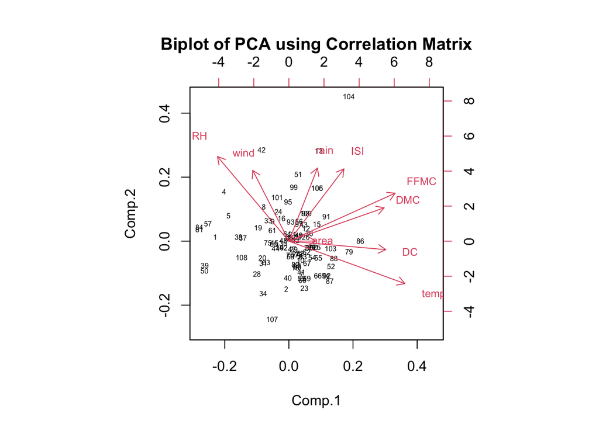

```r
## biplot
biplot(pca.cor, cex=c(.5, .75),
       main="Biplot of PCA using Correlation Matrix")
```

Contribute most to component 1: `temp`

Contribute most to component 2: `RH`

INTERPRETATION OF BIPLOT:

What’s the axes for the scatter points: (left&bottom or right&top)

What’s the meaning of the numbers on these axes:

- The values of the scores for each sample on the corresponding principal component.

What’s the meaning of the numbers on these axes:

- The values of the loadings for each variable on the corresponding principal component.

### 4.4 PART D

**Answer the question below:**

**What is the difference between loadings and scores in the context of PCA?**

ANSWER:

- Loadings - coefficients of the original variables in the principal components
- Scores - projection of the original data onto the principal components

**Extra Credit Opportunity: According to what we have learned in class, the arrows in the biplot represent the loadings of the variables, but in the biplot you created, the arrows are not pointing to the loadings, all the arrows seem a bit shorter than they should be. Can you explain why this is the case?**

ANSWER: The arrows are scaled. The information the relative length and the direction of the arrows convey matters, not the absolute length of the arrows. An unscaled biplot can also be produced.

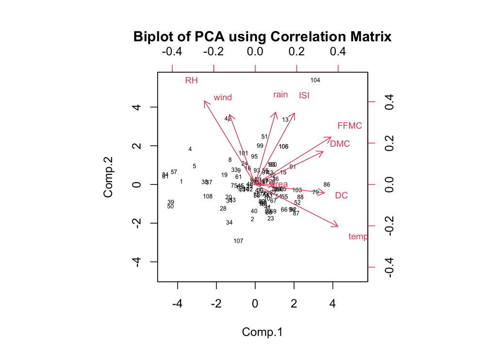

```r
biplot(pca.cor, cex=c(.5, .75), scale=0,
       main="Biplot of PCA using Correlation Matrix")
```